# DACON_Hospital_close_or_open_prediction

## Dacon - 병원 개/폐업 분류 예측

- https://dacon.io/competitions/official/9565/overview/

## 목적

- 의료기관이 폐업할지 안할지 여부를 예측

## 데이터 설명

- train.csv - 의료기관이 폐업했는지 여부를 포함하여 **최근 2개년의 재무정보와 병원 기본정보**
- test.csv - 폐업 여부를 제외하고 train.csv와 동일
- sample_submission.csv - inst_id와 open과 close를 예측하는 OC 두개의 열로 구성. OC의 값은 open 예측일 경우 1, close 예측일 경우 0.
- 훈련데이터 301개, 테스트데이터 127개의 비교적 적은 데이터

## 변수 설명

### (1) 병원정보 10개

- **inst_id - 각 파일에서의 병원 고유 번호**
- **OC – 영업/폐업 분류, 2018년 폐업은 2017년 폐업으로 간주함**
- sido – 병원의 광역 지역 정보
- sgg – 병원의 시군구 자료
- openDate – 병원 설립일
- bedCount - 병원이 갖추고 있는 병상의 수
- instkind – 병원, 의원(소병원), 요양병원, 한의원, 종합병원 등 병원의 종류

  > 종합병원 : 입원환자 100명 이상 수용 가능 (general_hospital)  
  > 일반병원 : 입원 환자 30명 이상 100명 미만 수용 가능 (hospital)  
  > 요양병원 : (nursing_hospital) 의원(소병원) : 입원 환자 30명 이하 수용 가능 (clinic)  
  > 한방 병원(한의원) : 침술과 한약으로 치료하는 의료 기관. (traditional_clinic)
- employee1 – 고용한 총 직원의 수, 2017(회계년도)년 데이터를 의미함
- employee2 – 고용한 총 직원의 수, 2016(회계년도)년 데이터를 의미함
- ownerChange – 대표자의 변동

### (2) 2017년 데이터 24개

- **revenue1 – 매출액**, 2017(회계년도)년 데이터를 의미함
- **salescost1** – 매출원가, 2017(회계년도)년 데이터를 의미함
- **sga1 - 판매비와 관리비**, 2017(회계년도)년 데이터를 의미함
- **salary1** – 급여, 2017(회계년도)년 데이터를 의미함
- **noi1** – 영업외수익, 2017(회계년도)년 데이터를 의미함
- **noe1** – 영업외비용, 2017(회계년도)년 데이터를 의미함
- Interest1 – 이자비용, 2017(회계년도)년 데이터를 의미함
- ctax1 – 법인세비용, 2017(회계년도)년 데이터를 의미함
- Profit1 – 당기순이익, 2017(회계년도)년 데이터를 의미함
- liquidAsset1 – 유동자산, 2017(회계년도)년 데이터를 의미함
- quickAsset1 – 당좌자산, 2017(회계년도)년 데이터를 의미함
- **receivableS1** - 미수금(단기), 2017(회계년도)년 데이터를 의미함
- inventoryAsset1 – 재고자산, 2017(회계년도)년 데이터를 의미함
- nonCAsset1 – 비유동자산, 2017(회계년도)년 데이터를 의미함
- tanAsset1 – 유형자산, 2017(회계년도)년 데이터를 의미함
- OnonCAsset1 - 기타 비유동자산, 2017(회계년도)년 데이터를 의미함
- **receivableL1** – 장기미수금, 2017(회계년도)년 데이터를 의미함
- debt1 – 부채총계, 2017(회계년도)년 데이터를 의미함
- liquidLiabilities1 – 유동부채, 2017(회계년도)년 데이터를 의미함
- shortLoan1 – 단기차입금, 2017(회계년도)년 데이터를 의미함
- NCLiabilities1 – 비유동부채, 2017(회계년도)년 데이터를 의미함
- longLoan1 – 장기차입금, 2017(회계년도)년 데이터를 의미함
- **netAsset1** – 순자산총계, 2017(회계년도)년 데이터를 의미함
- surplus1 – 이익잉여금, 2017(회계년도)년 데이터를 의미함

### (3) 2016년 데이터 24개

- **revenue2** – 매출액, 2016(회계년도)년 데이터를 의미함
- **salescost2** – 매출원가, 2016(회계년도)년 데이터를 의미함
- **sga2** - 판매비와 관리비, 2016(회계년도)년 데이터를 의미함
- **salary2** – 급여, 2016(회계년도)년 데이터를 의미함
- **noi2** – 영업외수익, 2016(회계년도)년 데이터를 의미함
- **noe2** – 영업외비용, 2016(회계년도)년 데이터를 의미함
- interest2 – 이자비용, 2016(회계년도)년 데이터를 의미함
- ctax2 – 법인세비용, 2016(회계년도)년 데이터를 의미함
- profit2 – 당기순이익, 2016(회계년도)년 데이터를 의미함
- liquidAsset2 – 유동자산, 2016(회계년도)년 데이터를 의미함
- quickAsset2 – 당좌자산, 2016(회계년도)년 데이터를 의미함
- **receivableS2** - 미수금(단기), 2016(회계년도)년 데이터를 의미함
- inventoryAsset2 – 재고자산, 2016(회계년도)년 데이터를 의미함
- nonCAsset2 – 비유동자산, 2016(회계년도)년 데이터를 의미함
- tanAsset2 – 유형자산, 2016(회계년도)년 데이터를 의미함
- OnonCAsset2 - 기타 비유동자산, 2016(회계년도)년 데이터를 의미함
- **receivableL2** – 장기미수금, 2016(회계년도)년 데이터를 의미함
- Debt2 – 부채총계, 2016(회계년도)년 데이터를 의미함
- liquidLiabilities2 – 유동부채, 2016(회계년도)년 데이터를 의미함
- shortLoan2 – 단기차입금, 2016(회계년도)년 데이터를 의미함
- NCLiabilities2 – 비유동부채, 2016(회계년도)년 데이터를 의미함
- longLoan2 – 장기차입금, 2016(회계년도)년 데이터를 의미함
- **netAsset2** – 순자산총계, 2016(회계년도)년 데이터를 의미함
- surplus2 – 이익잉여금, 2016(회계년도)년 데이터를 의미함

```python
import os
import numpy as np
import pandas as pd

os.chdir('C:\\Users\\urse\\Desktop\\dataset\\Daycon-Hospital_Opening_closing_classification_prediction')

# 1. 데이터 로딩
train_df = pd.read_csv('train.csv')
test_df = pd.read_csv('test.csv')

print('데이터 로딩 완료')
```

```
데이터 로딩 완료
```

```python
# 2. 훈련 데이터 파악하기 - (1) train.shape / train,head()
print(train_df.shape)
train_df.head()
```

```
(301, 58)
```

|  | inst_id | OC | sido | sgg | openDate | bedCount | instkind | revenue1 | salescost1 | sga1 | ... | debt2 | liquidLiabilities2 | shortLoan2 | NCLiabilities2 | longLoan2 | netAsset2 | surplus2 | employee1 | employee2 | ownerChange |
| --- | --- | --- | --- | --- | --- | --- | --- | --- | --- | --- | --- | --- | --- | --- | --- | --- | --- | --- | --- | --- | --- |
| 0 | 1 | open | choongnam | 73 | 20071228 | 175.0 | nursing_hospital | 4.217530e+09 | 0.0 | 3.961135e+09 | ... | 7.589937e+08 | 2.228769e+08 | 0.000000e+00 | 5.361169e+08 | 3.900000e+08 | 2.619290e+09 | 1.271224e+09 | 62.0 | 64.0 | same |
| 1 | 3 | open | gyeongnam | 32 | 19970401 | 410.0 | general_hospital | NaN | NaN | NaN | ... | NaN | NaN | NaN | NaN | NaN | NaN | NaN | 801.0 | 813.0 | same |
| 2 | 4 | open | gyeonggi | 89 | 20161228 | 468.0 | nursing_hospital | 1.004522e+09 | 515483669.0 | 4.472197e+08 | ... | 0.000000e+00 | 0.000000e+00 | 0.000000e+00 | 0.000000e+00 | 0.000000e+00 | 0.000000e+00 | 0.000000e+00 | 234.0 | 1.0 | same |
| 3 | 7 | open | incheon | 141 | 20000814 | 353.0 | general_hospital | 7.250734e+10 | 0.0 | 7.067740e+10 | ... | 3.775501e+10 | 1.701860e+10 | 9.219427e+09 | 2.073641e+10 | 1.510000e+10 | 1.295427e+10 | 7.740829e+09 | 663.0 | 663.0 | same |
| 4 | 9 | open | gyeongnam | 32 | 20050901 | 196.0 | general_hospital | 4.904354e+10 | 0.0 | 4.765605e+10 | ... | 5.143259e+10 | 3.007259e+10 | 1.759375e+10 | 2.136001e+10 | 1.410803e+10 | 5.561941e+06 | 9.025550e+09 | 206.0 | 197.0 | same |

5 rows × 58 columns

```python
# 2. 테스트 데이터 파악하기 - (1) test.shape / test.head()
print(test_df.shape)
test_df.head()
```

```
(127, 58)
```

|  | inst_id | OC | sido | sgg | openDate | bedCount | instkind | revenue1 | salescost1 | sga1 | ... | debt2 | liquidLiabilities2 | shortLoan2 | NCLiabilities2 | longLoan2 | netAsset2 | surplus2 | employee1 | employee2 | ownerChange |
| --- | --- | --- | --- | --- | --- | --- | --- | --- | --- | --- | --- | --- | --- | --- | --- | --- | --- | --- | --- | --- | --- |
| 0 | 2 | NaN | incheon | 139 | 19981125.0 | 300.0 | general_hospital | 6.682486e+10 | 0.000000e+00 | 6.565709e+10 | ... | 5.540643e+10 | 5.068443e+10 | 3.714334e+10 | 4.720000e+09 | 4.690000e+09 | 1.608540e+10 | 8.944587e+09 | 693 | 693 | same |
| 1 | 5 | NaN | jeju | 149 | 20160309.0 | 44.0 | hospital | 3.495758e+10 | 0.000000e+00 | 3.259270e+10 | ... | 6.730838e+10 | 4.209828e+10 | 2.420000e+10 | 2.521009e+10 | 1.830000e+10 | 3.789135e+09 | 0.000000e+00 | 379 | 371 | same |
| 2 | 6 | NaN | jeonnam | 103 | 19890427.0 | 276.0 | general_hospital | 2.326031e+10 | 2.542571e+09 | 2.308749e+10 | ... | 0.000000e+00 | 2.777589e+10 | 2.182278e+10 | 0.000000e+00 | 0.000000e+00 | 0.000000e+00 | 1.638540e+10 | NaN | NaN | NaN |
| 3 | 8 | NaN | busan | 71 | 20100226.0 | 363.0 | general_hospital | 0.000000e+00 | 0.000000e+00 | 0.000000e+00 | ... | 1.211517e+10 | 9.556237e+09 | 4.251867e+09 | 2.558931e+09 | 0.000000e+00 | 3.914284e+10 | 0.000000e+00 | 760 | 760 | same |
| 4 | 10 | NaN | jeonbuk | 26 | 20040604.0 | 213.0 | general_hospital | 5.037025e+10 | 0.000000e+00 | 4.855803e+10 | ... | 4.395973e+10 | 7.535567e+09 | 3.298427e+09 | 3.642417e+10 | 2.134712e+10 | 2.574488e+10 | 1.507269e+10 | 437 | 385 | same |

5 rows × 58 columns

```python
# # 2. 데이터 파악하기 - (2) dtypes 확인하기
print('############ train data dtypes ############ ')
print(train_df.dtypes)
```

```
############ train data dtypes ############
inst_id                 int64
OC                     object
sido                   object
sgg                     int64
openDate                int64
bedCount              float64
instkind               object
revenue1              float64
salescost1            float64
sga1                  float64
salary1               float64
noi1                  float64
noe1                  float64
interest1             float64
ctax1                 float64
profit1               float64
liquidAsset1          float64
quickAsset1           float64
receivableS1          float64
inventoryAsset1       float64
nonCAsset1            float64
tanAsset1             float64
OnonCAsset1           float64
receivableL1          float64
debt1                 float64
liquidLiabilities1    float64
shortLoan1            float64
NCLiabilities1        float64
longLoan1             float64
netAsset1             float64
surplus1              float64
revenue2              float64
salescost2            float64
sga2                  float64
salary2               float64
noi2                  float64
noe2                  float64
interest2             float64
ctax2                 float64
profit2               float64
liquidAsset2          float64
quickAsset2           float64
receivableS2          float64
inventoryAsset2       float64
nonCAsset2            float64
tanAsset2             float64
OnonCAsset2           float64
receivableL2          float64
debt2                 float64
liquidLiabilities2    float64
shortLoan2            float64
NCLiabilities2        float64
longLoan2             float64
netAsset2             float64
surplus2              float64
employee1             float64
employee2             float64
ownerChange            object
dtype: object
```

```python
# # 2. 데이터 파악하기 - (2) dtypes 확인하기
print('############ test data dtypes ############ ')
print(test_df.dtypes)
```

```
############ test data dtypes ############
inst_id                 int64
OC                    float64
sido                   object
sgg                     int64
openDate              float64
bedCount              float64
instkind               object
revenue1              float64
salescost1            float64
sga1                  float64
salary1               float64
noi1                  float64
noe1                  float64
interest1             float64
ctax1                 float64
profit1               float64
liquidAsset1          float64
quickAsset1           float64
receivableS1          float64
inventoryAsset1       float64
nonCAsset1            float64
tanAsset1             float64
OnonCAsset1           float64
receivableL1          float64
debt1                 float64
liquidLiabilities1    float64
shortLoan1            float64
NCLiabilities1        float64
longLoan1             float64
netAsset1             float64
surplus1              float64
revenue2              float64
salescost2            float64
sga2                  float64
salary2               float64
noi2                  float64
noe2                  float64
interest2             float64
ctax2                 float64
profit2               float64
liquidAsset2          float64
quickAsset2           float64
receivableS2          float64
inventoryAsset2       float64
nonCAsset2            float64
tanAsset2             float64
OnonCAsset2           float64
receivableL2          float64
debt2                 float64
liquidLiabilities2    float64
shortLoan2            float64
NCLiabilities2        float64
longLoan2             float64
netAsset2             float64
surplus2              float64
employee1              object
employee2              object
ownerChange            object
dtype: object
```

```python
# 2. 데이터 파악하기 - (4) 고유값 출력해보기 (dtypes - factor형 - 수치형 변수들 제외하고)
# 수치형 데이터들은 너무 광범위하니까.
print('############ train unique data ############ ')
for i in train_df.columns:
    if train_df[i].dtypes != np.float64 and train_df[i].dtypes != np.int64:
        print(i,'의 고유값들', train_df[i].unique(), '\n')

print('############ test unique data ############ ')
for i in test_df.columns:
    if test_df[i].dtypes != np.float64 and test_df[i].dtypes != np.int64:
        print(i,'의 고유값들', test_df[i].unique(), '\n')
```

```
############ train unique data ############
OC 의 고유값들 ['open' ' close']

sido 의 고유값들 ['choongnam' 'gyeongnam' 'gyeonggi' 'incheon' 'busan' 'jeonnam' 'seoul'
 'jeonbuk' 'choongbuk' 'ulsan' 'daejeon' 'daegu' 'gyeongbuk' 'gangwon'
 'gwangju' 'sejong']

instkind 의 고유값들 ['nursing_hospital' 'general_hospital' 'hospital' 'traditional_clinic'
 'clinic' 'traditional_hospital' 'dental_clinic' nan]

ownerChange 의 고유값들 ['same' 'change' nan]

############ test unique data ############
sido 의 고유값들 ['incheon' 'jeju' 'jeonnam' 'busan' 'jeonbuk' 'gyeonggi' 'gyeongbuk'
 'daejeon' 'seoul' 'daegu' 'choongbuk' 'ulsan' 'gyeongnam' 'choongnam'
 'sejong']

instkind 의 고유값들 ['general_hospital' 'hospital' 'nursing_hospital' 'traditional_clinic'
 'clinic' nan 'traditional_hospital']

employee1 의 고유값들 ['693' '379' nan '760' '437' '386' '727' '377' '17' '532' '128' '1,637'
 '1,816' '566' '104' '244' '187' '431' '150' '361' '41' '110' '457' '210'
 '344' '250' '48' '109' '292' '121' '83' '100' '154' '134' '107' '89' '86'
 '69' '93' '324' '1,065' '340' '55' '22' '300' '120' '260' '143' '78' '81'
 '46' '74' '155' '130' '122' '59' '180' '855' '30' '96' '75' '44' '203'
 '70' '129' '67' '85' '236' '29' '116' '37' '25' '45' '47' '52' '56' '76'
 '125' '80' '63' '90' '190' '222' '32' '66' '224' '61' '28' '604' '33'
 '16' '36' '106' '60' '19' '49' '21' '111' '560' '132' '363']

employee2 의 고유값들 ['693' '371' nan '760' '385' '397' '580' '346' '17' '409' '127' '1,547'
 '1,104' '566' '100' '258' '165' '412' '235' '41' '190' '112' '457' '149'
 '280' '260' '52' '109' '292' '121' '85' '82' '42' '55' '95' '96' '72'
 '324' '1,065' '340' '24' '300' '120' '240' '143' '79' '78' '200' '74'
 '49' '150' '125' '108' '117' '59' '191' '855' '30' '37' '188' '0' '70'
 '46' '134' '65' '87' '236' '75' '26' '45' '47' '54' '83' '81' '90' '170'
 '222' '32' '67' '66' '239' '130' '25' '604' '56' '20' '63' '16' '103'
 '68' '98' '57' '19' '40' '21' '111' '137' '343']

ownerChange 의 고유값들 ['same' nan 'change']
```

```python
# 2. 데이터 파악하기 - (4) 수치형 데이터 다양한 계산 값 보여줌
train_numeric_list = [] # 수치형 데이터 변수 리스트
test_numeric_list = [] # 수치형 데이터 변수 리스트

train_numeric_list.append(train_df.columns[5])
#train_numeric_list.extend(train_df.columns[7:-27])
train_numeric_list.extend(train_df.columns[7:-1])
print('훈련 데이터 수치값들 계산')
print(train_numeric_list)

print('\n테스트 데이터 수치값들 계산')
test_numeric_list.append(test_df.columns[5])
#test_numeric_list.extend(test_df.columns[7:-27])
test_numeric_list.extend(test_df.columns[7: -1])
print(test_numeric_list)
```

[output not shown]

```python
print('############ train describe ############ ')
train_df_numeric = train_df[train_numeric_list]
train_df_numeric.describe()
```

```
############ train describe ############
```

|  | bedCount | revenue1 | salescost1 | sga1 | salary1 | noi1 | noe1 | interest1 | ctax1 | profit1 | ... | receivableL2 | debt2 | liquidLiabilities2 | shortLoan2 | NCLiabilities2 | longLoan2 | netAsset2 | surplus2 | employee1 | employee2 |
| --- | --- | --- | --- | --- | --- | --- | --- | --- | --- | --- | --- | --- | --- | --- | --- | --- | --- | --- | --- | --- | --- |
| count | 296.000000 | 2.930000e+02 | 2.930000e+02 | 2.930000e+02 | 2.930000e+02 | 2.930000e+02 | 2.930000e+02 | 2.930000e+02 | 2.930000e+02 | 2.930000e+02 | ... | 2.930000e+02 | 2.930000e+02 | 2.930000e+02 | 2.930000e+02 | 2.930000e+02 | 2.930000e+02 | 2.930000e+02 | 2.930000e+02 | 291.000000 | 288.000000 |
| mean | 145.709459 | 1.288175e+10 | 2.014903e+09 | 1.033244e+10 | 5.654115e+09 | 2.696151e+08 | 5.115870e+08 | 1.868966e+08 | 7.847322e+07 | 2.101700e+08 | ... | 2.226700e+05 | 8.146026e+09 | 3.860584e+09 | 1.510050e+09 | 4.471247e+09 | 2.709979e+09 | 5.273919e+09 | 9.786279e+08 | 142.546392 | 134.326389 |
| std | 118.923890 | 2.043543e+10 | 7.460271e+09 | 1.493886e+10 | 8.083343e+09 | 8.023701e+08 | 1.060379e+09 | 2.738658e+08 | 2.486102e+08 | 1.134673e+09 | ... | 3.811496e+06 | 1.255800e+10 | 6.797242e+09 | 2.953412e+09 | 7.659580e+09 | 4.564001e+09 | 1.081259e+10 | 4.688798e+09 | 160.191073 | 151.061786 |
| min | 0.000000 | 0.000000e+00 | 0.000000e+00 | 0.000000e+00 | 0.000000e+00 | 0.000000e+00 | 0.000000e+00 | 0.000000e+00 | 0.000000e+00 | -4.696701e+09 | ... | 0.000000e+00 | 0.000000e+00 | 0.000000e+00 | 0.000000e+00 | 0.000000e+00 | 0.000000e+00 | -2.014780e+10 | -2.781507e+09 | 0.000000 | 0.000000 |
| 25% | 52.750000 | 3.252112e+09 | 0.000000e+00 | 2.758201e+09 | 1.626053e+09 | 8.217133e+06 | 8.013395e+07 | 5.066474e+07 | 0.000000e+00 | -2.168279e+06 | ... | 0.000000e+00 | 1.283220e+09 | 2.855741e+08 | 0.000000e+00 | 2.557878e+07 | 0.000000e+00 | 1.017573e+09 | 0.000000e+00 | 53.500000 | 53.750000 |
| 50% | 136.500000 | 5.524218e+09 | 2.104105e+08 | 4.684074e+09 | 2.659892e+09 | 4.363764e+07 | 1.831965e+08 | 1.097329e+08 | 1.024900e+06 | 8.130751e+07 | ... | 0.000000e+00 | 3.784553e+09 | 1.454050e+09 | 8.542549e+07 | 1.969747e+09 | 1.100000e+09 | 2.894970e+09 | 0.000000e+00 | 80.000000 | 79.000000 |
| 75% | 193.000000 | 1.274839e+10 | 9.105278e+08 | 1.077876e+10 | 6.363400e+09 | 2.050331e+08 | 4.203330e+08 | 2.242308e+08 | 4.435396e+07 | 2.930329e+08 | ... | 0.000000e+00 | 8.465053e+09 | 4.364714e+09 | 1.567967e+09 | 4.905441e+09 | 3.360000e+09 | 5.370285e+09 | 1.014447e+08 | 181.500000 | 170.000000 |
| max | 656.000000 | 1.510000e+11 | 9.850332e+10 | 1.030000e+11 | 6.403559e+10 | 9.144171e+09 | 8.686380e+09 | 2.841475e+09 | 2.808883e+09 | 7.475427e+09 | ... | 6.524231e+07 | 8.508858e+10 | 6.846878e+10 | 1.759375e+10 | 5.150388e+10 | 3.256147e+10 | 1.250000e+11 | 6.852730e+10 | 1200.000000 | 1200.000000 |

8 rows × 51 columns

```python
print('############ test describe ############ ')
test_df_numeric = test_df[test_numeric_list]
test_df_numeric.describe()
```

```
############ test describe ############
```

|  | bedCount | revenue1 | salescost1 | sga1 | salary1 | noi1 | noe1 | interest1 | ctax1 | profit1 | ... | tanAsset2 | OnonCAsset2 | receivableL2 | debt2 | liquidLiabilities2 | shortLoan2 | NCLiabilities2 | longLoan2 | netAsset2 | surplus2 |
| --- | --- | --- | --- | --- | --- | --- | --- | --- | --- | --- | --- | --- | --- | --- | --- | --- | --- | --- | --- | --- | --- |
| count | 119.000000 | 1.250000e+02 | 1.250000e+02 | 1.250000e+02 | 1.250000e+02 | 1.250000e+02 | 1.250000e+02 | 1.250000e+02 | 1.250000e+02 | 1.250000e+02 | ... | 1.250000e+02 | 1.250000e+02 | 1.250000e+02 | 1.250000e+02 | 1.250000e+02 | 1.250000e+02 | 1.250000e+02 | 1.250000e+02 | 1.250000e+02 | 1.250000e+02 |
| mean | 172.789916 | 1.824446e+10 | 3.973321e+09 | 1.340410e+10 | 7.415084e+09 | 5.175513e+08 | 8.704307e+08 | 3.168253e+08 | 1.148616e+08 | 3.940712e+08 | ... | 1.336209e+10 | 3.513831e+08 | 1.973114e+04 | 1.189851e+10 | 5.633432e+09 | 2.181713e+09 | 6.495026e+09 | 4.482682e+09 | 6.116179e+09 | 1.648474e+09 |
| std | 126.024471 | 3.133530e+10 | 1.419948e+10 | 2.054481e+10 | 1.210043e+10 | 1.193139e+09 | 1.804461e+09 | 4.587781e+08 | 3.089796e+08 | 1.813462e+09 | ... | 2.085404e+10 | 9.791097e+08 | 2.206009e+05 | 1.971182e+10 | 9.662048e+09 | 4.952449e+09 | 1.203673e+10 | 7.517020e+09 | 9.813461e+09 | 4.779444e+09 |
| min | 0.000000 | 0.000000e+00 | 0.000000e+00 | 0.000000e+00 | 0.000000e+00 | 0.000000e+00 | 0.000000e+00 | 0.000000e+00 | 0.000000e+00 | -5.734451e+09 | ... | 0.000000e+00 | 0.000000e+00 | 0.000000e+00 | 0.000000e+00 | 0.000000e+00 | 0.000000e+00 | 0.000000e+00 | 0.000000e+00 | -2.955957e+09 | -8.600000e+09 |
| 25% | 94.000000 | 3.235889e+09 | 0.000000e+00 | 3.083860e+09 | 1.666742e+09 | 1.641094e+07 | 8.365552e+07 | 5.259163e+07 | 0.000000e+00 | 1.060223e+07 | ... | 2.807763e+09 | 0.000000e+00 | 0.000000e+00 | 1.679896e+09 | 3.914156e+08 | 0.000000e+00 | 1.321368e+08 | 0.000000e+00 | 9.492656e+08 | 0.000000e+00 |
| 50% | 156.000000 | 6.637116e+09 | 1.896923e+08 | 5.716502e+09 | 3.263054e+09 | 5.319171e+07 | 2.315190e+08 | 1.507859e+08 | 8.433480e+06 | 1.463808e+08 | ... | 5.450483e+09 | 3.317377e+07 | 0.000000e+00 | 4.494217e+09 | 1.554506e+09 | 3.000000e+08 | 2.030000e+09 | 1.750000e+09 | 2.427139e+09 | 0.000000e+00 |
| 75% | 213.000000 | 1.704039e+10 | 1.192329e+09 | 1.445243e+10 | 7.198103e+09 | 3.714592e+08 | 6.633503e+08 | 3.384277e+08 | 5.994202e+07 | 4.525557e+08 | ... | 1.187114e+10 | 2.048998e+08 | 0.000000e+00 | 1.412031e+10 | 6.586241e+09 | 2.650000e+09 | 5.700000e+09 | 4.857048e+09 | 5.881965e+09 | 6.935165e+08 |
| max | 771.000000 | 1.810000e+11 | 1.160000e+11 | 1.270000e+11 | 8.239561e+10 | 7.302719e+09 | 1.149680e+10 | 2.573804e+09 | 2.308489e+09 | 1.120816e+10 | ... | 1.130000e+11 | 7.112780e+09 | 2.466393e+06 | 1.310000e+11 | 5.241427e+10 | 3.714334e+10 | 7.855654e+10 | 3.620288e+10 | 4.924492e+10 | 2.561787e+10 |

8 rows × 49 columns

```python
# 2. 데이터 파악하기 - (5) 훈련데이터 상관관계

import matplotlib
import matplotlib.pyplot as plt
import seaborn as sns

### 데이터간의 상관관계 출력
corr = train_df_numeric.corr()
corr
```

|  | bedCount | revenue1 | salescost1 | sga1 | salary1 | noi1 | noe1 | interest1 | ctax1 | profit1 | ... | receivableL2 | debt2 | liquidLiabilities2 | shortLoan2 | NCLiabilities2 | longLoan2 | netAsset2 | surplus2 | employee1 | employee2 |
| --- | --- | --- | --- | --- | --- | --- | --- | --- | --- | --- | --- | --- | --- | --- | --- | --- | --- | --- | --- | --- | --- |
| bedCount | 1.000000 | 0.289082 | 0.078792 | 0.349943 | 0.404217 | 0.201880 | 0.193827 | 0.263906 | 0.058007 | 0.034148 | ... | 0.018199 | 0.275485 | 0.272860 | 0.171153 | 0.233065 | 0.215910 | 0.229840 | 0.002476 | 0.549031 | 0.519291 |
| revenue1 | 0.289082 | 1.000000 | 0.763828 | 0.948704 | 0.887745 | 0.488480 | 0.547292 | 0.395143 | 0.532650 | 0.194505 | ... | -0.030880 | 0.790688 | 0.671424 | 0.335311 | 0.707237 | 0.335618 | 0.673484 | 0.379391 | 0.848154 | 0.840224 |
| salescost1 | 0.078792 | 0.763828 | 1.000000 | 0.529645 | 0.442412 | 0.293315 | 0.313329 | 0.066624 | 0.276444 | 0.038196 | ... | -0.013725 | 0.422473 | 0.362502 | 0.076776 | 0.377095 | 0.059127 | 0.468871 | 0.150657 | 0.535739 | 0.532871 |
| sga1 | 0.349943 | 0.948704 | 0.529645 | 1.000000 | 0.965193 | 0.493348 | 0.537183 | 0.488017 | 0.524206 | 0.153972 | ... | -0.027650 | 0.833485 | 0.712273 | 0.409504 | 0.740522 | 0.404109 | 0.660272 | 0.415082 | 0.864533 | 0.862690 |
| salary1 | 0.404217 | 0.887745 | 0.442412 | 0.965193 | 1.000000 | 0.507201 | 0.539640 | 0.469107 | 0.461356 | 0.113468 | ... | -0.024818 | 0.808134 | 0.670240 | 0.409030 | 0.741377 | 0.387288 | 0.668894 | 0.373222 | 0.884563 | 0.876730 |
| noi1 | 0.201880 | 0.488480 | 0.293315 | 0.493348 | 0.507201 | 1.000000 | 0.840733 | 0.152248 | 0.265460 | 0.239735 | ... | -0.010663 | 0.458584 | 0.332232 | 0.105521 | 0.452160 | 0.165080 | 0.340956 | 0.141026 | 0.522974 | 0.529463 |
| noe1 | 0.193827 | 0.547292 | 0.313329 | 0.537183 | 0.539640 | 0.840733 | 1.000000 | 0.359191 | 0.337355 | 0.313376 | ... | 0.001388 | 0.596683 | 0.487194 | 0.254266 | 0.548493 | 0.312184 | 0.377614 | 0.199671 | 0.533973 | 0.528779 |
| interest1 | 0.263906 | 0.395143 | 0.066624 | 0.488017 | 0.469107 | 0.152248 | 0.359191 | 1.000000 | 0.051729 | 0.013775 | ... | 0.070095 | 0.693078 | 0.760793 | 0.596777 | 0.467005 | 0.658538 | 0.175255 | 0.126441 | 0.385146 | 0.390909 |
| ctax1 | 0.058007 | 0.532650 | 0.276444 | 0.524206 | 0.461356 | 0.265460 | 0.337355 | 0.051729 | 1.000000 | 0.512296 | ... | -0.018503 | 0.410067 | 0.205193 | 0.024254 | 0.490033 | 0.086753 | 0.475964 | 0.663385 | 0.384629 | 0.347599 |
| profit1 | 0.034148 | 0.194505 | 0.038196 | 0.153972 | 0.113468 | 0.239735 | 0.313376 | 0.013775 | 0.512296 | 1.000000 | ... | -0.106463 | 0.153791 | 0.057241 | -0.026656 | 0.196159 | 0.140613 | 0.119960 | 0.124502 | 0.143322 | 0.056874 |
| liquidAsset1 | 0.169083 | 0.849537 | 0.648095 | 0.786382 | 0.708509 | 0.435608 | 0.514582 | 0.263684 | 0.618822 | 0.360438 | ... | 0.012989 | 0.678120 | 0.556981 | 0.192748 | 0.619278 | 0.235644 | 0.717177 | 0.439476 | 0.698564 | 0.679400 |
| quickAsset1 | 0.169954 | 0.843240 | 0.647131 | 0.778300 | 0.702156 | 0.435246 | 0.513567 | 0.256409 | 0.617696 | 0.360752 | ... | 0.014392 | 0.670644 | 0.549871 | 0.186904 | 0.613572 | 0.230819 | 0.713984 | 0.434108 | 0.694581 | 0.674033 |
| receivableS1 | 0.172038 | 0.462395 | 0.250743 | 0.501636 | 0.500986 | 0.119875 | 0.198398 | 0.144111 | 0.286821 | -0.104439 | ... | -0.026957 | 0.454073 | 0.314412 | 0.149689 | 0.461369 | 0.198595 | 0.622188 | 0.402682 | 0.415174 | 0.454918 |
| inventoryAsset1 | 0.109060 | 0.799205 | 0.517458 | 0.798326 | 0.698290 | 0.344189 | 0.421138 | 0.382772 | 0.500198 | 0.207538 | ... | -0.022267 | 0.697874 | 0.599096 | 0.294171 | 0.608681 | 0.294015 | 0.619562 | 0.463439 | 0.636897 | 0.654223 |
| nonCAsset1 | 0.335061 | 0.767375 | 0.421387 | 0.807164 | 0.821312 | 0.424878 | 0.533425 | 0.537746 | 0.462421 | 0.108869 | ... | 0.001917 | 0.867735 | 0.672637 | 0.406455 | 0.830724 | 0.492282 | 0.836137 | 0.476621 | 0.750646 | 0.751941 |
| tanAsset1 | 0.362251 | 0.723044 | 0.383806 | 0.769554 | 0.801923 | 0.421520 | 0.527282 | 0.561891 | 0.349893 | 0.085023 | ... | -0.022683 | 0.847310 | 0.674421 | 0.425282 | 0.796062 | 0.518369 | 0.809119 | 0.344789 | 0.742357 | 0.744299 |
| OnonCAsset1 | 0.138420 | 0.624425 | 0.490421 | 0.591363 | 0.517249 | 0.234116 | 0.312003 | 0.299566 | 0.237473 | 0.039957 | ... | -0.021336 | 0.513947 | 0.531622 | 0.269608 | 0.363997 | 0.248902 | 0.259773 | 0.120749 | 0.511427 | 0.530019 |
| receivableL1 | 0.018199 | -0.030880 | -0.013725 | -0.027650 | -0.024818 | -0.010663 | 0.001388 | 0.070095 | -0.018503 | -0.106463 | ... | 1.000000 | -0.035042 | 0.021900 | -0.029972 | -0.034220 | -0.034807 | -0.028593 | -0.012235 | -0.014514 | NaN |
| debt1 | 0.316835 | 0.786963 | 0.453118 | 0.814186 | 0.805431 | 0.474411 | 0.635517 | 0.696268 | 0.295950 | 0.144326 | ... | -0.037307 | 0.952324 | 0.805237 | 0.486560 | 0.830339 | 0.677740 | 0.544550 | 0.213092 | 0.741764 | 0.739619 |
| liquidLiabilities1 | 0.331541 | 0.759557 | 0.464762 | 0.778898 | 0.733606 | 0.268320 | 0.448610 | 0.694612 | 0.248715 | 0.074355 | ... | 0.028559 | 0.808159 | 0.895694 | 0.689274 | 0.567629 | 0.520612 | 0.415623 | 0.200899 | 0.684996 | 0.703529 |
| shortLoan1 | 0.243236 | 0.352606 | 0.151312 | 0.398584 | 0.392435 | 0.056275 | 0.213734 | 0.553814 | 0.023916 | -0.060082 | ... | -0.032264 | 0.449162 | 0.622899 | 0.831054 | 0.262988 | 0.337409 | 0.121471 | 0.136035 | 0.342776 | 0.390657 |
| NCLiabilities1 | 0.266507 | 0.667948 | 0.363811 | 0.696153 | 0.723421 | 0.551743 | 0.673581 | 0.573627 | 0.279454 | 0.169201 | ... | -0.034238 | 0.879913 | 0.618288 | 0.302876 | 0.879774 | 0.668189 | 0.538873 | 0.189961 | 0.665276 | 0.648579 |
| longLoan1 | 0.199130 | 0.308927 | 0.060065 | 0.366774 | 0.362941 | 0.159315 | 0.318008 | 0.757982 | 0.068989 | 0.142990 | ... | -0.033027 | 0.698026 | 0.568766 | 0.325133 | 0.626011 | 0.790187 | 0.206523 | 0.069568 | 0.311963 | 0.280987 |
| netAsset1 | 0.197907 | 0.656025 | 0.427265 | 0.651069 | 0.636740 | 0.312138 | 0.328938 | 0.143319 | 0.632260 | 0.187656 | ... | -0.027495 | 0.553995 | 0.337380 | 0.092937 | 0.597483 | 0.104991 | 0.941897 | 0.641063 | 0.593534 | 0.585822 |
| surplus1 | -0.027866 | 0.331676 | 0.141113 | 0.361112 | 0.311386 | 0.096600 | 0.104526 | 0.049228 | 0.678585 | 0.090010 | ... | -0.008997 | 0.322851 | 0.122339 | 0.074560 | 0.421901 | 0.005635 | 0.426114 | 0.952722 | 0.203004 | 0.203185 |
| revenue2 | 0.270627 | 0.987402 | 0.756414 | 0.937460 | 0.878868 | 0.499467 | 0.552275 | 0.394974 | 0.511813 | 0.172696 | ... | -0.023548 | 0.797762 | 0.687819 | 0.357909 | 0.706266 | 0.329849 | 0.687489 | 0.377707 | 0.835454 | 0.837899 |
| salescost2 | 0.090680 | 0.771633 | 0.994907 | 0.543902 | 0.464013 | 0.297372 | 0.312898 | 0.070823 | 0.276018 | 0.027697 | ... | -0.011786 | 0.434413 | 0.370684 | 0.088870 | 0.391587 | 0.063438 | 0.495995 | 0.161345 | 0.554367 | 0.554548 |
| sga2 | 0.329928 | 0.930753 | 0.530323 | 0.977083 | 0.946305 | 0.509729 | 0.556598 | 0.494117 | 0.463575 | 0.136480 | ... | -0.019299 | 0.839574 | 0.740488 | 0.439806 | 0.727650 | 0.407437 | 0.658634 | 0.364749 | 0.848417 | 0.860267 |
| salary2 | 0.370559 | 0.872931 | 0.444395 | 0.945421 | 0.979092 | 0.515324 | 0.544912 | 0.459219 | 0.444185 | 0.098902 | ... | -0.016829 | 0.813449 | 0.684075 | 0.431899 | 0.739828 | 0.376368 | 0.687676 | 0.376440 | 0.858639 | 0.864419 |
| noi2 | 0.204972 | 0.679811 | 0.422959 | 0.678640 | 0.690865 | 0.667931 | 0.631497 | 0.152982 | 0.526036 | 0.287975 | ... | -0.023543 | 0.555718 | 0.381648 | 0.086649 | 0.565777 | 0.092473 | 0.586248 | 0.379432 | 0.634994 | 0.624346 |
| noe2 | 0.173097 | 0.668630 | 0.329705 | 0.683138 | 0.657902 | 0.622986 | 0.753554 | 0.372026 | 0.671519 | 0.463518 | ... | 0.054264 | 0.685801 | 0.499276 | 0.274685 | 0.682955 | 0.293693 | 0.516956 | 0.532184 | 0.588432 | 0.537170 |
| interest2 | 0.235331 | 0.394796 | 0.062862 | 0.489002 | 0.464761 | 0.124192 | 0.327643 | 0.954603 | 0.050712 | 0.029055 | ... | 0.124584 | 0.690278 | 0.773674 | 0.635322 | 0.457468 | 0.644294 | 0.168169 | 0.131203 | 0.367569 | 0.389867 |
| ctax2 | 0.017684 | 0.574227 | 0.396019 | 0.533904 | 0.465415 | 0.303058 | 0.333748 | 0.009542 | 0.879134 | 0.402793 | ... | -0.016492 | 0.400716 | 0.236224 | 0.022709 | 0.445235 | -0.025495 | 0.482793 | 0.642111 | 0.396828 | 0.384836 |
| profit2 | -0.023178 | 0.350066 | 0.180335 | 0.315068 | 0.226832 | 0.131712 | 0.210105 | -0.010993 | 0.788783 | 0.688576 | ... | -0.157418 | 0.238250 | 0.095317 | -0.027398 | 0.298914 | 0.036661 | 0.352877 | 0.524253 | 0.186053 | 0.131940 |
| liquidAsset2 | 0.168323 | 0.829474 | 0.641749 | 0.761672 | 0.693886 | 0.491077 | 0.543949 | 0.277243 | 0.562027 | 0.394639 | ... | 0.026049 | 0.692300 | 0.565148 | 0.201401 | 0.634474 | 0.270924 | 0.677894 | 0.364871 | 0.687911 | 0.662070 |
| quickAsset2 | 0.168725 | 0.821251 | 0.639535 | 0.751606 | 0.685612 | 0.491666 | 0.541794 | 0.266231 | 0.559432 | 0.396797 | ... | 0.027527 | 0.681678 | 0.555264 | 0.190333 | 0.626054 | 0.262990 | 0.672850 | 0.356303 | 0.685933 | 0.658606 |
| receivableS2 | 0.203553 | 0.408198 | 0.170045 | 0.473333 | 0.482498 | 0.200590 | 0.153088 | 0.081722 | 0.121667 | -0.033515 | ... | -0.023567 | 0.347212 | 0.305541 | 0.085700 | 0.291271 | 0.135025 | 0.583364 | 0.146681 | 0.428021 | 0.465009 |
| inventoryAsset2 | 0.095291 | 0.788705 | 0.526175 | 0.779309 | 0.678373 | 0.364993 | 0.436711 | 0.348592 | 0.506717 | 0.209567 | ... | -0.011970 | 0.692891 | 0.577074 | 0.291075 | 0.620264 | 0.293458 | 0.623612 | 0.490714 | 0.605333 | 0.618561 |
| nonCAsset2 | 0.313005 | 0.744193 | 0.398619 | 0.792521 | 0.806874 | 0.390683 | 0.504954 | 0.546922 | 0.417802 | 0.044527 | ... | 0.005417 | 0.875149 | 0.703771 | 0.443202 | 0.819623 | 0.517270 | 0.838543 | 0.461638 | 0.725454 | 0.742542 |
| tanAsset2 | 0.339334 | 0.703109 | 0.367921 | 0.755796 | 0.786431 | 0.375514 | 0.488394 | 0.564130 | 0.313584 | 0.021116 | ... | -0.020070 | 0.851718 | 0.703582 | 0.456058 | 0.781945 | 0.534442 | 0.816989 | 0.337127 | 0.717566 | 0.734626 |
| OnonCAsset2 | 0.126992 | 0.596700 | 0.454623 | 0.566988 | 0.494383 | 0.194708 | 0.338666 | 0.332636 | 0.218486 | 0.049724 | ... | -0.021574 | 0.537825 | 0.512690 | 0.310796 | 0.420731 | 0.340252 | 0.224522 | 0.131556 | 0.470332 | 0.491681 |
| receivableL2 | 0.018199 | -0.030880 | -0.013725 | -0.027650 | -0.024818 | -0.010663 | 0.001388 | 0.070095 | -0.018503 | -0.106463 | ... | 1.000000 | -0.035042 | 0.021900 | -0.029972 | -0.034220 | -0.034807 | -0.028593 | -0.012235 | -0.014514 | NaN |
| debt2 | 0.275485 | 0.790688 | 0.422473 | 0.833485 | 0.808134 | 0.458584 | 0.596683 | 0.693078 | 0.410067 | 0.153791 | ... | -0.035042 | 1.000000 | 0.823775 | 0.512327 | 0.892872 | 0.698678 | 0.573993 | 0.383228 | 0.709531 | 0.712118 |
| liquidLiabilities2 | 0.272860 | 0.671424 | 0.362502 | 0.712273 | 0.670240 | 0.332232 | 0.487194 | 0.760793 | 0.205193 | 0.057241 | ... | 0.021900 | 0.823775 | 1.000000 | 0.747963 | 0.506810 | 0.459790 | 0.393577 | 0.200435 | 0.609385 | 0.642262 |
| shortLoan2 | 0.171153 | 0.335311 | 0.076776 | 0.409504 | 0.409030 | 0.105521 | 0.254266 | 0.596777 | 0.024254 | -0.026656 | ... | -0.029972 | 0.512327 | 0.747963 | 1.000000 | 0.263592 | 0.321915 | 0.120721 | 0.136217 | 0.313959 | 0.347681 |
| NCLiabilities2 | 0.233065 | 0.707237 | 0.377095 | 0.740522 | 0.741377 | 0.452160 | 0.548493 | 0.467005 | 0.490033 | 0.196159 | ... | -0.034220 | 0.892872 | 0.506810 | 0.263592 | 1.000000 | 0.723052 | 0.579945 | 0.458595 | 0.640558 | 0.617945 |
| longLoan2 | 0.215910 | 0.335618 | 0.059127 | 0.404109 | 0.387288 | 0.165080 | 0.312184 | 0.658538 | 0.086753 | 0.140613 | ... | -0.034807 | 0.698678 | 0.459790 | 0.321915 | 0.723052 | 1.000000 | 0.142624 | 0.068171 | 0.321289 | 0.298944 |
| netAsset2 | 0.229840 | 0.673484 | 0.468871 | 0.660272 | 0.668894 | 0.340956 | 0.377614 | 0.175255 | 0.475964 | 0.119960 | ... | -0.028593 | 0.573993 | 0.393577 | 0.120721 | 0.579945 | 0.142624 | 1.000000 | 0.457233 | 0.647032 | 0.652978 |
| surplus2 | 0.002476 | 0.379391 | 0.150657 | 0.415082 | 0.373222 | 0.141026 | 0.199671 | 0.126441 | 0.663385 | 0.124502 | ... | -0.012235 | 0.383228 | 0.200435 | 0.136217 | 0.458595 | 0.068171 | 0.457233 | 1.000000 | 0.261380 | 0.264987 |
| employee1 | 0.549031 | 0.848154 | 0.535739 | 0.864533 | 0.884563 | 0.522974 | 0.533973 | 0.385146 | 0.384629 | 0.143322 | ... | -0.014514 | 0.709531 | 0.609385 | 0.313959 | 0.640558 | 0.321289 | 0.647032 | 0.261380 | 1.000000 | 0.973681 |
| employee2 | 0.519291 | 0.840224 | 0.532871 | 0.862690 | 0.876730 | 0.529463 | 0.528779 | 0.390909 | 0.347599 | 0.056874 | ... | NaN | 0.712118 | 0.642262 | 0.347681 | 0.617945 | 0.298944 | 0.652978 | 0.264987 | 0.973681 | 1.000000 |

51 rows × 51 columns

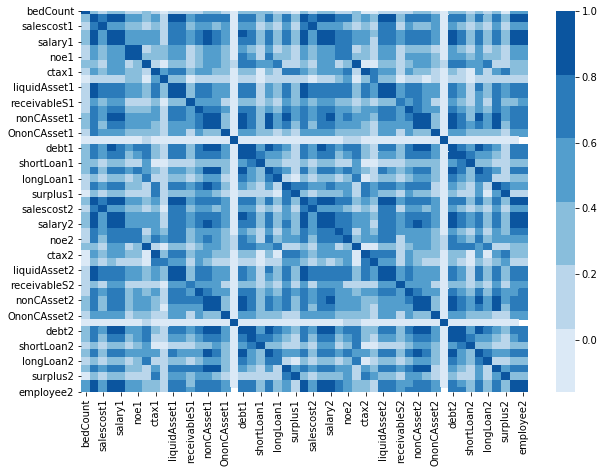

```python
# 2. 데이터 파악하기 - (5) 시각화를 통한 데이터 상관관계 히트맵
cmap = sns.color_palette("Blues")
f, ax = plt.subplots(figsize=(10,7))
sns.heatmap(corr, cmap=cmap)
```

```python
# 2. 데이터 파악하기 - (5) 테스트 데이터 상관관계
corr2 = test_df_numeric.corr()
corr2
```

|  | bedCount | revenue1 | salescost1 | sga1 | salary1 | noi1 | noe1 | interest1 | ctax1 | profit1 | ... | tanAsset2 | OnonCAsset2 | receivableL2 | debt2 | liquidLiabilities2 | shortLoan2 | NCLiabilities2 | longLoan2 | netAsset2 | surplus2 |
| --- | --- | --- | --- | --- | --- | --- | --- | --- | --- | --- | --- | --- | --- | --- | --- | --- | --- | --- | --- | --- | --- |
| bedCount | 1.000000 | 0.426953 | 0.386365 | 0.356885 | 0.283885 | 0.447871 | 0.453370 | 0.193945 | 0.303370 | 0.124932 | ... | 0.458998 | 0.169136 | -0.113741 | 0.465030 | 0.400116 | 0.115854 | 0.461435 | 0.257694 | 0.417402 | 0.028325 |
| revenue1 | 0.426953 | 1.000000 | 0.775871 | 0.900612 | 0.853234 | 0.579267 | 0.636545 | 0.468318 | 0.764039 | 0.602924 | ... | 0.764555 | 0.532520 | -0.049351 | 0.845699 | 0.794917 | 0.311734 | 0.749766 | 0.579818 | 0.715633 | 0.519835 |
| salescost1 | 0.386365 | 0.775871 | 1.000000 | 0.430116 | 0.359986 | 0.512968 | 0.488692 | 0.138122 | 0.660912 | 0.413163 | ... | 0.527334 | 0.437811 | -0.025230 | 0.692466 | 0.631460 | 0.125069 | 0.624997 | 0.256394 | 0.555329 | 0.283932 |
| sga1 | 0.356885 | 0.900612 | 0.430116 | 1.000000 | 0.977418 | 0.483667 | 0.544703 | 0.592350 | 0.614950 | 0.534195 | ... | 0.745088 | 0.446732 | -0.054156 | 0.744078 | 0.717031 | 0.376584 | 0.651878 | 0.658578 | 0.644666 | 0.544300 |
| salary1 | 0.283885 | 0.853234 | 0.359986 | 0.977418 | 1.000000 | 0.417287 | 0.518522 | 0.524829 | 0.613621 | 0.505111 | ... | 0.677233 | 0.447162 | -0.050442 | 0.663612 | 0.640354 | 0.337098 | 0.579408 | 0.623865 | 0.587523 | 0.479386 |
| noi1 | 0.447871 | 0.579267 | 0.512968 | 0.483667 | 0.417287 | 1.000000 | 0.652537 | 0.353537 | 0.426493 | 0.432310 | ... | 0.615020 | 0.227243 | -0.038665 | 0.584465 | 0.588317 | 0.361145 | 0.503431 | 0.336201 | 0.687709 | 0.276488 |
| noe1 | 0.453370 | 0.636545 | 0.488692 | 0.544703 | 0.518522 | 0.652537 | 1.000000 | 0.280709 | 0.573142 | 0.316903 | ... | 0.489866 | 0.399054 | -0.043168 | 0.573406 | 0.561154 | 0.279636 | 0.494213 | 0.322259 | 0.425119 | 0.098201 |
| interest1 | 0.193945 | 0.468318 | 0.138122 | 0.592350 | 0.524829 | 0.353537 | 0.280709 | 1.000000 | 0.084587 | 0.244404 | ... | 0.631135 | 0.194153 | -0.061945 | 0.604864 | 0.538255 | 0.526390 | 0.579423 | 0.699001 | 0.381843 | 0.450397 |
| ctax1 | 0.303370 | 0.764039 | 0.660912 | 0.614950 | 0.613621 | 0.426493 | 0.573142 | 0.084587 | 1.000000 | 0.576454 | ... | 0.421317 | 0.458660 | -0.032546 | 0.511055 | 0.524144 | 0.128226 | 0.409045 | 0.196813 | 0.557400 | 0.429454 |
| profit1 | 0.124932 | 0.602924 | 0.413163 | 0.534195 | 0.505111 | 0.432310 | 0.316903 | 0.244404 | 0.576454 | 1.000000 | ... | 0.477638 | 0.378734 | -0.018343 | 0.472146 | 0.391976 | 0.076261 | 0.432325 | 0.423741 | 0.639849 | 0.610472 |
| liquidAsset1 | 0.382588 | 0.887026 | 0.810689 | 0.707603 | 0.649585 | 0.647659 | 0.614562 | 0.330924 | 0.809345 | 0.618277 | ... | 0.655220 | 0.479401 | -0.049886 | 0.759434 | 0.810424 | 0.387920 | 0.613030 | 0.373768 | 0.721992 | 0.536222 |
| quickAsset1 | 0.375204 | 0.886059 | 0.809018 | 0.706653 | 0.651162 | 0.644496 | 0.614759 | 0.320360 | 0.817015 | 0.621793 | ... | 0.648096 | 0.475958 | -0.049295 | 0.752252 | 0.801380 | 0.375508 | 0.606342 | 0.366849 | 0.720732 | 0.534617 |
| receivableS1 | 0.251230 | 0.395421 | 0.194255 | 0.453492 | 0.498720 | 0.317025 | 0.336675 | 0.114539 | 0.149917 | 0.024102 | ... | 0.372382 | 0.174497 | -0.035234 | 0.319753 | 0.313525 | 0.105174 | 0.325772 | 0.287175 | 0.282702 | 0.008932 |
| inventoryAsset1 | 0.459899 | 0.705231 | 0.657002 | 0.571224 | 0.469976 | 0.571983 | 0.455897 | 0.499136 | 0.450876 | 0.400521 | ... | 0.669163 | 0.454962 | -0.050196 | 0.740270 | 0.820439 | 0.585938 | 0.619552 | 0.449006 | 0.589689 | 0.460771 |
| nonCAsset1 | 0.513539 | 0.797439 | 0.598783 | 0.742351 | 0.666073 | 0.636726 | 0.506130 | 0.604753 | 0.460560 | 0.507173 | ... | 0.961424 | 0.273605 | -0.060958 | 0.922513 | 0.811302 | 0.419092 | 0.870201 | 0.721254 | 0.852470 | 0.427997 |
| tanAsset1 | 0.510811 | 0.777112 | 0.551980 | 0.746874 | 0.675210 | 0.625896 | 0.485128 | 0.601842 | 0.433105 | 0.491282 | ... | 0.971820 | 0.198663 | -0.060519 | 0.908224 | 0.797322 | 0.420329 | 0.858657 | 0.719596 | 0.859776 | 0.423898 |
| OnonCAsset1 | 0.161586 | 0.545554 | 0.423938 | 0.474529 | 0.458838 | 0.276087 | 0.378779 | 0.311692 | 0.439635 | 0.454875 | ... | 0.253238 | 0.953208 | -0.017164 | 0.379957 | 0.306532 | 0.090469 | 0.371263 | 0.421963 | 0.280455 | 0.319034 |
| receivableL1 | -0.119250 | -0.039961 | -0.022888 | -0.040228 | -0.036355 | -0.035748 | -0.039668 | -0.046636 | -0.033786 | -0.033577 | ... | -0.040593 | -0.017793 | 0.000123 | -0.044012 | -0.047759 | -0.037216 | -0.035476 | -0.033095 | -0.027750 | -0.031354 |
| debt1 | 0.507286 | 0.861610 | 0.702263 | 0.763993 | 0.682319 | 0.598531 | 0.578320 | 0.601851 | 0.525562 | 0.446733 | ... | 0.901456 | 0.365276 | -0.059344 | 0.974775 | 0.870539 | 0.453780 | 0.884631 | 0.689345 | 0.738793 | 0.355296 |
| liquidLiabilities1 | 0.401760 | 0.823685 | 0.565801 | 0.806834 | 0.760633 | 0.586603 | 0.538032 | 0.573182 | 0.475595 | 0.422003 | ... | 0.813726 | 0.332293 | -0.053241 | 0.834138 | 0.920028 | 0.641889 | 0.661880 | 0.535779 | 0.672321 | 0.387950 |
| shortLoan1 | 0.194785 | 0.375253 | 0.110702 | 0.476986 | 0.460010 | 0.419582 | 0.312795 | 0.583827 | 0.136249 | 0.154128 | ... | 0.509181 | 0.140431 | -0.046903 | 0.472535 | 0.688419 | 0.875451 | 0.283369 | 0.327403 | 0.338624 | 0.256195 |
| NCLiabilities1 | 0.540568 | 0.730099 | 0.701526 | 0.573739 | 0.468682 | 0.510672 | 0.509866 | 0.533200 | 0.463667 | 0.352617 | ... | 0.825026 | 0.327103 | -0.055647 | 0.912044 | 0.689552 | 0.246342 | 0.927993 | 0.697918 | 0.645506 | 0.313610 |
| longLoan1 | 0.236203 | 0.406879 | 0.229192 | 0.434438 | 0.360956 | 0.194719 | 0.176514 | 0.630472 | 0.115069 | 0.253318 | ... | 0.564490 | 0.338182 | -0.063905 | 0.584871 | 0.391167 | 0.240614 | 0.630042 | 0.816255 | 0.377474 | 0.409861 |
| netAsset1 | 0.383640 | 0.692929 | 0.526167 | 0.621590 | 0.577504 | 0.650588 | 0.407921 | 0.338759 | 0.578803 | 0.728238 | ... | 0.785782 | 0.229203 | -0.049664 | 0.676654 | 0.579719 | 0.176186 | 0.630111 | 0.514296 | 0.959946 | 0.524004 |
| surplus1 | 0.054806 | 0.549810 | 0.284828 | 0.578245 | 0.508593 | 0.275918 | 0.152439 | 0.462526 | 0.460521 | 0.676663 | ... | 0.412427 | 0.278647 | -0.032147 | 0.375823 | 0.452573 | 0.301061 | 0.300561 | 0.382237 | 0.480852 | 0.953484 |
| revenue2 | 0.431786 | 0.995551 | 0.784102 | 0.888195 | 0.838105 | 0.605148 | 0.649187 | 0.455152 | 0.763534 | 0.605880 | ... | 0.775300 | 0.532031 | -0.048292 | 0.855049 | 0.811019 | 0.321575 | 0.754300 | 0.570533 | 0.727530 | 0.500766 |
| salescost2 | 0.396005 | 0.775424 | 0.999174 | 0.429284 | 0.359476 | 0.514332 | 0.495519 | 0.134504 | 0.665514 | 0.414401 | ... | 0.529230 | 0.445902 | -0.025233 | 0.694720 | 0.633188 | 0.123722 | 0.626113 | 0.255920 | 0.558733 | 0.273009 |
| sga2 | 0.343170 | 0.902824 | 0.444047 | 0.990554 | 0.969313 | 0.516283 | 0.572827 | 0.571221 | 0.629091 | 0.560193 | ... | 0.754604 | 0.460793 | -0.052195 | 0.755618 | 0.742522 | 0.396720 | 0.652763 | 0.646778 | 0.655914 | 0.525837 |
| salary2 | 0.268267 | 0.848204 | 0.362334 | 0.967259 | 0.992987 | 0.443303 | 0.537175 | 0.506639 | 0.616029 | 0.512420 | ... | 0.680526 | 0.453540 | -0.048672 | 0.666175 | 0.653629 | 0.353632 | 0.575168 | 0.615350 | 0.589868 | 0.458454 |
| noi2 | 0.443723 | 0.743011 | 0.660584 | 0.611628 | 0.558849 | 0.749662 | 0.574414 | 0.325215 | 0.617255 | 0.533632 | ... | 0.692530 | 0.253897 | -0.037190 | 0.738099 | 0.733039 | 0.369411 | 0.616434 | 0.336287 | 0.763635 | 0.400744 |
| noe2 | 0.506821 | 0.680116 | 0.656189 | 0.500978 | 0.444284 | 0.600602 | 0.892806 | 0.277636 | 0.568913 | 0.320269 | ... | 0.605615 | 0.310769 | -0.041678 | 0.730587 | 0.706819 | 0.329486 | 0.635054 | 0.309504 | 0.494999 | 0.080595 |
| interest2 | 0.168432 | 0.464009 | 0.128337 | 0.585922 | 0.523965 | 0.369208 | 0.254749 | 0.944115 | 0.093919 | 0.353744 | ... | 0.682276 | 0.198768 | -0.052260 | 0.627009 | 0.493043 | 0.434363 | 0.642116 | 0.748626 | 0.457183 | 0.459092 |
| ctax2 | 0.297884 | 0.670681 | 0.680237 | 0.474913 | 0.449617 | 0.468089 | 0.480795 | 0.057178 | 0.873580 | 0.538757 | ... | 0.435676 | 0.314692 | -0.031916 | 0.529515 | 0.548397 | 0.138626 | 0.421272 | 0.124816 | 0.595453 | 0.429768 |
| profit2 | 0.280605 | 0.655778 | 0.465836 | 0.594651 | 0.536537 | 0.424216 | 0.280490 | 0.251592 | 0.605104 | 0.841295 | ... | 0.506173 | 0.320287 | -0.023756 | 0.487507 | 0.369100 | -0.024516 | 0.478316 | 0.416782 | 0.708504 | 0.683718 |
| liquidAsset2 | 0.425748 | 0.850289 | 0.841048 | 0.639781 | 0.556980 | 0.639089 | 0.579035 | 0.315323 | 0.730353 | 0.555502 | ... | 0.674157 | 0.388544 | -0.045225 | 0.788305 | 0.831547 | 0.384187 | 0.645664 | 0.336698 | 0.727467 | 0.506921 |
| quickAsset2 | 0.421189 | 0.847853 | 0.839825 | 0.636629 | 0.555093 | 0.635996 | 0.578024 | 0.304815 | 0.735913 | 0.556641 | ... | 0.667478 | 0.383164 | -0.044789 | 0.781615 | 0.825883 | 0.376362 | 0.638293 | 0.327897 | 0.726408 | 0.506594 |
| receivableS2 | 0.181589 | 0.407642 | 0.204086 | 0.468470 | 0.511887 | 0.188187 | 0.249307 | 0.076758 | 0.173439 | -0.013296 | ... | 0.349704 | 0.187337 | -0.033408 | 0.310475 | 0.351398 | 0.149009 | 0.289454 | 0.215418 | 0.256587 | 0.058232 |
| inventoryAsset2 | 0.443202 | 0.783964 | 0.700002 | 0.653895 | 0.563401 | 0.604632 | 0.497008 | 0.545976 | 0.487252 | 0.462715 | ... | 0.723685 | 0.493735 | -0.049220 | 0.804463 | 0.830327 | 0.541703 | 0.695355 | 0.520514 | 0.641196 | 0.480671 |
| nonCAsset2 | 0.468558 | 0.788599 | 0.577102 | 0.744275 | 0.672952 | 0.630008 | 0.510466 | 0.626246 | 0.448272 | 0.495779 | ... | 0.994520 | 0.270260 | -0.055205 | 0.947195 | 0.807711 | 0.434761 | 0.915304 | 0.784990 | 0.848939 | 0.411356 |
| tanAsset2 | 0.458998 | 0.764555 | 0.527334 | 0.745088 | 0.677233 | 0.615020 | 0.489866 | 0.631135 | 0.421317 | 0.477638 | ... | 1.000000 | 0.193088 | -0.054585 | 0.929728 | 0.793838 | 0.440731 | 0.897762 | 0.778950 | 0.847677 | 0.407684 |
| OnonCAsset2 | 0.169136 | 0.532520 | 0.437811 | 0.446732 | 0.447162 | 0.227243 | 0.399054 | 0.194153 | 0.458660 | 0.378734 | ... | 0.193088 | 1.000000 | -0.013677 | 0.348802 | 0.320283 | 0.098740 | 0.315362 | 0.360823 | 0.204156 | 0.226709 |
| receivableL2 | -0.113741 | -0.049351 | -0.025230 | -0.054156 | -0.050442 | -0.038665 | -0.043168 | -0.061945 | -0.032546 | -0.018343 | ... | -0.054585 | -0.013677 | 1.000000 | -0.053893 | -0.051867 | -0.039720 | -0.048345 | -0.053276 | -0.046525 | -0.031098 |
| debt2 | 0.465030 | 0.845699 | 0.692466 | 0.744078 | 0.663612 | 0.584465 | 0.573406 | 0.604864 | 0.511055 | 0.472146 | ... | 0.929728 | 0.348802 | -0.053893 | 1.000000 | 0.860574 | 0.437482 | 0.935088 | 0.740019 | 0.737113 | 0.347407 |
| liquidLiabilities2 | 0.400116 | 0.794917 | 0.631460 | 0.717031 | 0.640354 | 0.588317 | 0.561154 | 0.538255 | 0.524144 | 0.391976 | ... | 0.793838 | 0.320283 | -0.051867 | 0.860574 | 1.000000 | 0.736729 | 0.648821 | 0.465265 | 0.639482 | 0.407665 |
| shortLoan2 | 0.115854 | 0.311734 | 0.125069 | 0.376584 | 0.337098 | 0.361145 | 0.279636 | 0.526390 | 0.128226 | 0.076261 | ... | 0.440731 | 0.098740 | -0.039720 | 0.437482 | 0.736729 | 1.000000 | 0.198549 | 0.231271 | 0.250716 | 0.285203 |
| NCLiabilities2 | 0.461435 | 0.749766 | 0.624997 | 0.651878 | 0.579408 | 0.503431 | 0.494213 | 0.579423 | 0.409045 | 0.432325 | ... | 0.897762 | 0.315362 | -0.048345 | 0.935088 | 0.648821 | 0.198549 | 1.000000 | 0.826909 | 0.681768 | 0.299425 |
| longLoan2 | 0.257694 | 0.579818 | 0.256394 | 0.658578 | 0.623865 | 0.336201 | 0.322259 | 0.699001 | 0.196813 | 0.423741 | ... | 0.778950 | 0.360823 | -0.053276 | 0.740019 | 0.465265 | 0.231271 | 0.826909 | 1.000000 | 0.544381 | 0.370984 |
| netAsset2 | 0.417402 | 0.715633 | 0.555329 | 0.644666 | 0.587523 | 0.687709 | 0.425119 | 0.381843 | 0.557400 | 0.639849 | ... | 0.847677 | 0.204156 | -0.046525 | 0.737113 | 0.639482 | 0.250716 | 0.681768 | 0.544381 | 1.000000 | 0.504938 |
| surplus2 | 0.028325 | 0.519835 | 0.283932 | 0.544300 | 0.479386 | 0.276488 | 0.098201 | 0.450397 | 0.429454 | 0.610472 | ... | 0.407684 | 0.226709 | -0.031098 | 0.347407 | 0.407665 | 0.285203 | 0.299425 | 0.370984 | 0.504938 | 1.000000 |

49 rows × 49 columns

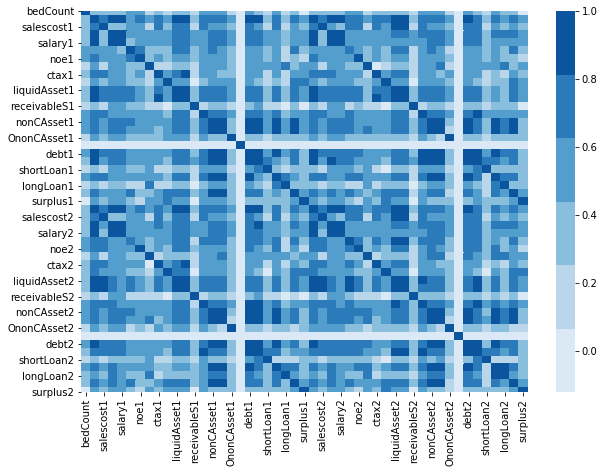

```python
# 2. 데이터 파악하기 - (5) 시각화를 통한 데이터 상관관계 히트맵
cmap = sns.color_palette("Blues")
f2, ax2 = plt.subplots(figsize=(10,7))
sns.heatmap(corr2, cmap=cmap)
```

### 2. 데이터 탐색 결론

```python
# 3. 데이터 전처리 - (1) employee 변수들 object 변수에서 -> float &  OC close 변수 공백없애기.
train_df.employee1 = train_df.employee1.astype('float')
train_df.employee2 = train_df.employee2.astype('float')
train_df.OC = train_df.OC.astype('str').str.replace(' ', '') # close 데이터에 앞이 띄어져 있어서 공백이 있어서.

test_df.employee1 = test_df.employee1.astype('str').str.replace(',', '').astype('float')
test_df.employee2 = test_df.employee2.astype('str').str.replace(',', '').astype('float')

print('데이터 전처리 employee 변수들 object 변수에서 -> float &  OC close 변수 공백없애기 완료')
```

```
데이터 전처리 employee 변수들 object 변수에서 -> float &  OC close 변수 공백없애기 완료
```

```python
# 3. 데이터 전처리 - (2) factor, numeric columns 구분
# 수치형 변수들은 특정 값으로 (0) / 범주형 변수 NA는 특정 문자열로

# Combining the train and test data
# 데이터 전처리 값 처리 등 더 편하기 위해서 잠깐 합침.
train_test_prod = train_df.append(test_df)

# Get the object and numeric columns seperately
# object 타입과 정수형 타입들의 columns들 골라내기
factor_columns = train_test_prod.select_dtypes(include=['object']).columns
numeric_columns = train_test_prod.columns.difference(factor_columns)

print('### factor_columns \n', factor_columns, len(factor_columns))
print('### numeric_columns \n', numeric_columns, len(numeric_columns))
```

```
### factor_columns
 Index(['OC', 'sido', 'instkind', 'ownerChange'], dtype='object') 4
### numeric_columns
 Index(['NCLiabilities1', 'NCLiabilities2', 'OnonCAsset1', 'OnonCAsset2',
       'bedCount', 'ctax1', 'ctax2', 'debt1', 'debt2', 'employee1',
       'employee2', 'inst_id', 'interest1', 'interest2', 'inventoryAsset1',
       'inventoryAsset2', 'liquidAsset1', 'liquidAsset2', 'liquidLiabilities1',
       'liquidLiabilities2', 'longLoan1', 'longLoan2', 'netAsset1',
       'netAsset2', 'noe1', 'noe2', 'noi1', 'noi2', 'nonCAsset1', 'nonCAsset2',
       'openDate', 'profit1', 'profit2', 'quickAsset1', 'quickAsset2',
       'receivableL1', 'receivableL2', 'receivableS1', 'receivableS2',
       'revenue1', 'revenue2', 'salary1', 'salary2', 'salescost1',
       'salescost2', 'sga1', 'sga2', 'sgg', 'shortLoan1', 'shortLoan2',
       'surplus1', 'surplus2', 'tanAsset1', 'tanAsset2'],
      dtype='object') 54
```

```python
# 3. 데이터 전처리 - (3) NA , NULL 값 등 처리

# 데이터 430번은 dental_clinic 인데 잘못 적혀 있었음.
# 데이터 413번은 Bedcount가 비어 있어서 채워줌.
train_test_prod.loc[train_test_prod.inst_id == 430, ['instkind']] = 'dental_clinic'
train_test_prod.loc[train_test_prod.inst_id == 430, ['bedCount']] = 0
train_test_prod.loc[train_test_prod.inst_id == 413, ['bedCount']] = 0

#Fill the empty values in the object columns as "Not sure"
# 범주형 변수들 NA를 Not sure 로 채움.
train_test_prod[factor_columns] = train_test_prod[factor_columns].fillna('Not_sure')

# 정수형 변수들 -999로 채워둠.
#Fill all the empty values in the numeric columns as -999
train_test_prod[numeric_columns] = train_test_prod[numeric_columns].fillna(0)

print('데이터 전처리 - (3) NA , NULL 값 등 처리 완료')
```

```
데이터 전처리 - (3) NA , NULL 값 등 처리 완료
```

```python
# 3. 데이터 전처리 - (4) Object columns LabelEncoder()로 변환하기

from sklearn.preprocessing import LabelEncoder

# 범주형 변수들 목록 : 'OC', 'sido', 'instkind', 'ownerChange'
# Convert all the object columns to numeric since the ML algorithms don't accept object features directly
fac_le = LabelEncoder()
train_test_prod[factor_columns] = train_test_prod.loc[:,factor_columns].apply(lambda x : fac_le.fit_transform(x))
train_test_prod.head()
```

|  | inst_id | OC | sido | sgg | openDate | bedCount | instkind | revenue1 | salescost1 | sga1 | ... | debt2 | liquidLiabilities2 | shortLoan2 | NCLiabilities2 | longLoan2 | netAsset2 | surplus2 | employee1 | employee2 | ownerChange |
| --- | --- | --- | --- | --- | --- | --- | --- | --- | --- | --- | --- | --- | --- | --- | --- | --- | --- | --- | --- | --- | --- |
| 0 | 1 | 2 | 2 | 73 | 20071228.0 | 175.0 | 5 | 4.217530e+09 | 0.0 | 3.961135e+09 | ... | 7.589937e+08 | 2.228769e+08 | 0.000000e+00 | 5.361169e+08 | 3.900000e+08 | 2.619290e+09 | 1.271224e+09 | 62.0 | 64.0 | 2 |
| 1 | 3 | 2 | 9 | 32 | 19970401.0 | 410.0 | 3 | 0.000000e+00 | 0.0 | 0.000000e+00 | ... | 0.000000e+00 | 0.000000e+00 | 0.000000e+00 | 0.000000e+00 | 0.000000e+00 | 0.000000e+00 | 0.000000e+00 | 801.0 | 813.0 | 2 |
| 2 | 4 | 2 | 8 | 89 | 20161228.0 | 468.0 | 5 | 1.004522e+09 | 515483669.0 | 4.472197e+08 | ... | 0.000000e+00 | 0.000000e+00 | 0.000000e+00 | 0.000000e+00 | 0.000000e+00 | 0.000000e+00 | 0.000000e+00 | 234.0 | 1.0 | 2 |
| 3 | 7 | 2 | 10 | 141 | 20000814.0 | 353.0 | 3 | 7.250734e+10 | 0.0 | 7.067740e+10 | ... | 3.775501e+10 | 1.701860e+10 | 9.219427e+09 | 2.073641e+10 | 1.510000e+10 | 1.295427e+10 | 7.740829e+09 | 663.0 | 663.0 | 2 |
| 4 | 9 | 2 | 9 | 32 | 20050901.0 | 196.0 | 3 | 4.904354e+10 | 0.0 | 4.765605e+10 | ... | 5.143259e+10 | 3.007259e+10 | 1.759375e+10 | 2.136001e+10 | 1.410803e+10 | 5.561941e+06 | 9.025550e+09 | 206.0 | 197.0 | 2 |

5 rows × 58 columns

```python
# 3. 데이터 전처리 - (5) Object columns LabelEncoder()로 변환하기
# 다시 train_data, test_data 분리
# Splitting back data to train prod and test prod
train_prod = train_test_prod.loc[train_test_prod.OC != 0,]
test_prod = train_test_prod.loc[train_test_prod.OC == 0,]
train_prod['OC'] = train_prod['OC'] - 1

print('train_df', train_prod.shape)
print('test_df', test_prod.shape)
```

```
train_df (301, 58)
test_df (127, 58)
```

[output not shown]

```python
# 3. 데이터 전처리 - (6) 훈련 데이터 및 검증 데이터 생성

# dacon 제출용 submission id
#Obtain the submission ID to create the submission file later
sub_id = test_prod.inst_id # 병원 ID

# 종속변수, 특징변수 분리
answer = 'OC' # 훈련 데이터 정답 라벨
not_answer = train_prod.columns.difference([answer])  # OC를 제외한 columns list

# 훈련 데이터 / 훈련 데이터 정답 라벨 / 테스트 데이터 생성.
# OC 제외 데이터 / OC / OC 제외 데이터
train_prod_X = train_prod[not_answer] # 훈련 x
train_prod_Y = train_prod[answer] # 훈련 y
test_prod_X = test_prod[not_answer] # 테스트 x

print("데이터 전처리 - (6) 훈련 데이터 및 검증 데이터 생성 완료")
```

```
데이터 전처리 - (6) 훈련 데이터 및 검증 데이터 생성 완료
```

```python
# 4. 데이터 학습 - (0) 라이브러리 import
from sklearn.model_selection import train_test_split, StratifiedKFold, GridSearchCV
from sklearn.linear_model import LogisticRegression
from sklearn.ensemble import RandomForestClassifier, GradientBoostingClassifier
from sklearn import svm
from sklearn.metrics import confusion_matrix, accuracy_score, roc_auc_score
import shap
import xgboost as xgb
import seaborn as sns
import matplotlib.pyplot as plt

print('데이터 학습 - (0) 라이브러리 import 완료')
```

```
데이터 학습 - (0) 라이브러리 import 완료
```

### 앙상블 (ensemble)

- 앙상블 쓰는 이유 : 여러 개의 단일 모델들의 평균치를 내거나, 투표를 해서 다수결에 의한 결정을 하는 등 더 나은 결과를 도출해 내기 위한 목적기법
- 배깅방법과 부스팅 방법이 있고, 배깅에는 RandomForest / 부스팅방법에는 AdaBoost, GradientBoost(GBM) , AdaBoost, XGBoost, LightGradientBoost 등이 있음.

### (1) Bagging

- 샘플을 여러번 뽑아 각 모델을 학습시켜 결과를 집계
- 복원추출로 N개의 데이터셋을 만들고 N개의 모델을 만듬
- 다양한 데이터 셋 사용 하니까 Overfitting 방지
- Classification과 regression 모두 사용 가능

[figure not shown]

### (1) - 1. 랜덤 포레스트

[figure not shown]

### (2) Boosting

- 배깅의 변형으로 모델이 잘 예측하지 못하는 부분을 개선하기 위한 모델
- 이전 모델들이 예측하지 못한 Error data에 가중치를 부여하여, 다음 모델이 더 잘 예측되도록 하는 것.

[figure not shown]

### (3) 배깅 vs 부스팅

- Bagging은 일반적인 모델을 만드는데 집중되어 있는 반면, Boosting은 맞추기 어려운 문제를 맞추는데 초점이 맞춰져 있음.
- Boosting은 속도가 느리지만 Bagging에 비해 에러가 적고, 데이터를 사용한 걸 재사용하니 오버피팅 될 가능성이 있음.
- ==> 개별 결정 트리의 낮은 성능이 문제라면 Boosting / 오버피팅이 문제라면 Bagging

```python
############ Random Forest
# 4. 데이터 학습 - (1) Random Forest 변수 설정 및 학습 및 테스트

# 앙상블 배깅 랜덤포레스트 Bagging RandomForest
estimators = 100 # 분류기 갯수
np.random.seed(100)
RF_prod = RandomForestClassifier(n_estimators = estimators)

# 랜덤 포레스트 훈련 데이터 학습
RF_prod_model = RF_prod.fit(train_prod_X, train_prod_Y)

# 랜덤 포레스트 테스트 데이터 테스트
RF_prod_prediction = RF_prod.predict_proba(test_prod_X)[:,1]

# 제출용 파일 생성 (sub_id 는 test Id )
sub_RF = pd.DataFrame({'inst_id' : sub_id , 'OC' : RF_prod_prediction })
sub_RF = sub_RF[['inst_id', 'OC']]

print('모델 정보\n', RF_prod_model)
print('\n테스트 결과\n')
sub_RF.head()
#print("데이터 학습 - (1) Random Forest 변수 설정 및 학습 및 테스트 완료")
```

```
모델 정보
 RandomForestClassifier(bootstrap=True, ccp_alpha=0.0, class_weight=None,
                       criterion='gini', max_depth=None, max_features='auto',
                       max_leaf_nodes=None, max_samples=None,
                       min_impurity_decrease=0.0, min_impurity_split=None,
                       min_samples_leaf=1, min_samples_split=2,
                       min_weight_fraction_leaf=0.0, n_estimators=100,
                       n_jobs=None, oob_score=False, random_state=None,
                       verbose=0, warm_start=False)

테스트 결과
```

|  | inst_id | OC |
| --- | --- | --- |
| 0 | 2 | 0.97 |
| 1 | 5 | 0.79 |
| 2 | 6 | 0.54 |
| 3 | 8 | 0.78 |
| 4 | 10 | 0.96 |

```python
############ GBM: Gradient Boosting
# 4 데이터 학습 - (2) GBM 변수 설정 및 학습 및 테스트
# 부스팅 방법 중 GBM
GBM_prod = GradientBoostingClassifier(n_estimators = estimators)

# GBM 훈련 데이터 학습
GBM_prod_model = GBM_prod.fit(train_prod_X, train_prod_Y)

# GBM 테스트 데이터 테스트
GBM_prod_prediction = GBM_prod.predict_proba(test_prod_X)[:,1]

# 제출용 파일 생성
sub_GBM = pd.DataFrame({'inst_id' : sub_id , 'OC' : GBM_prod_prediction })
sub_GBM = sub_GBM[['inst_id', 'OC']]

print('모델 정보\n', GBM_prod_model)
print('\n GBM 테스트 결과\n')
sub_GBM

# print("데이터 학습 - (2) GBM 변수 설정 및 학습 및 테스트 완료")
```

```
모델 정보
 GradientBoostingClassifier(ccp_alpha=0.0, criterion='friedman_mse', init=None,
                           learning_rate=0.1, loss='deviance', max_depth=3,
                           max_features=None, max_leaf_nodes=None,
                           min_impurity_decrease=0.0, min_impurity_split=None,
                           min_samples_leaf=1, min_samples_split=2,
                           min_weight_fraction_leaf=0.0, n_estimators=100,
                           n_iter_no_change=None, presort='deprecated',
                           random_state=None, subsample=1.0, tol=0.0001,
                           validation_fraction=0.1, verbose=0,
                           warm_start=False)

 GBM 테스트 결과
```

|  | inst_id | OC |
| --- | --- | --- |
| 0 | 2 | 0.996271 |
| 1 | 5 | 0.507898 |
| 2 | 6 | 0.128696 |
| 3 | 8 | 0.999036 |
| 4 | 10 | 0.994699 |
| ... | ... | ... |
| 122 | 424 | 0.114661 |
| 123 | 425 | 0.963801 |
| 124 | 429 | 0.011534 |
| 125 | 430 | 0.939491 |
| 126 | 431 | 0.011534 |

127 rows × 2 columns

```python
############ XGBOOST
# GBM 보다 성능이 좀더 좋음. -> 더 좋은건 lgbm
# 4. 데이터 학습 - (3) XGBOOST 변수 설정 및 학습 및 테스트
dtrain_prod = xgb.DMatrix(data = train_prod_X, label = train_prod_Y)
dtest_prod = xgb.DMatrix(data = test_prod_X)

# Custom error function for the XGB model
threshold = 0.5
def eval_error(preds, dtrain):
    labels = dtrain.get_label()
    preds = (preds > threshold ).astype('float')
    return "accuracy", accuracy_score(labels, preds)

# xgboost - reg:linear(linear-regression / binary:logistic classification)
param = {'objective' : 'binary:logistic',  # 목적함수
         'max_depth' : 6, # leaf node 2^6 = 64
         'eta': 0.3, # learning late
         'colsample_bytree' : 1,
         'subsample' : 1,
         # 'silent' : 0 -> not be used error
         # eval_metrics : 모델의 평가 함수 조정하는 함수
         }

nrounds = 100 # epoch / 반복 라운드 결정

np.random.seed(100)

# xgb_model 학습
xgb_model = xgb.train(param,
                      dtrain_prod,
                      num_boost_round = nrounds , # = epoch 반복횟수
                      feval = eval_error,
                      #maximize = True,
                      #early_stopping_rounds = 10,
                      )

XGB_prediction = xgb_model.predict(dtest_prod)

sub_XGB= pd.DataFrame({'inst_id' : sub_id , 'OC' : XGB_prediction })
sub_XGB= sub_XGB[['inst_id', 'OC']]

print('\n XGBoost 테스트 결과\n')
sub_XGB

#print("데이터 학습 - (3) XGBOOST 변수 설정 및 학습 및 테스트 완료")
```

```
 XGBoost 테스트 결과
```

|  | inst_id | OC |
| --- | --- | --- |
| 0 | 2 | 0.997355 |
| 1 | 5 | 0.988993 |
| 2 | 6 | 0.797268 |
| 3 | 8 | 0.998132 |
| 4 | 10 | 0.990046 |
| ... | ... | ... |
| 122 | 424 | 0.062254 |
| 123 | 425 | 0.975678 |
| 124 | 429 | 0.646116 |
| 125 | 430 | 0.860324 |
| 126 | 431 | 0.473385 |

127 rows × 2 columns

```python
# 5. 데이터 앙상블 - (1) 각 기법 훈련 결과 csv로 통합 저장
#Forming the ensemble dataset of the 3 models
ensemble = pd.DataFrame()
ensemble['inst_id'] = sub_XGB['inst_id']
ensemble['RandomForest'] = sub_RF['OC']
ensemble['GBM'] = sub_GBM['OC']
ensemble['XGB'] = sub_XGB['OC']

# Taking the average of all 3 models
# 모델 3개 합치고 0.7미만인 것들은 폐업으로 예상
ensemble['ens'] = (ensemble['XGB'] + ensemble['GBM'] + ensemble['RandomForest'])/3
ensemble['OC'] = (ensemble['ens'] > 0.7).astype('int') #0.7 as the threshold and above that the hospital is closed.

ensemble.to_csv('hospital_submission.csv', index=False)
#ensemble.sort_values('ens', ascending=False)
ensemble
```

|  | inst_id | RandomForest | GBM | XGB | ens | OC |
| --- | --- | --- | --- | --- | --- | --- |
| 0 | 2 | 0.97 | 0.996271 | 0.997355 | 0.987875 | 1 |
| 1 | 5 | 0.79 | 0.507898 | 0.988993 | 0.762297 | 1 |
| 2 | 6 | 0.54 | 0.128696 | 0.797268 | 0.488655 | 0 |
| 3 | 8 | 0.78 | 0.999036 | 0.998132 | 0.925722 | 1 |
| 4 | 10 | 0.96 | 0.994699 | 0.990046 | 0.981582 | 1 |
| ... | ... | ... | ... | ... | ... | ... |
| 122 | 424 | 0.43 | 0.114661 | 0.062254 | 0.202305 | 0 |
| 123 | 425 | 0.82 | 0.963801 | 0.975678 | 0.919826 | 1 |
| 124 | 429 | 0.60 | 0.011534 | 0.646116 | 0.419216 | 0 |
| 125 | 430 | 0.78 | 0.939491 | 0.860324 | 0.859939 | 1 |
| 126 | 431 | 0.64 | 0.011534 | 0.473385 | 0.374973 | 0 |

127 rows × 6 columns

### 1. 목적

- 병원 2년치 재무정보 및 병원 기본정보 가지고 개/폐업 여부 분류 예측

### 2. 데이터 탐색

(1) Dataframe의 dtypes 함수 -> train data와 test data의 dtype이 다름  
(2) Dataframe의 Unique 함수 -> OC변수의 ' close' 변수 앞에 공백 있음  
(3) Dataframe의 Unique 함수 -> 데이터간의 NA, NULL 값 존재.  
(4) Dataframe의 Unique 함수 -> 훈련데이터에서 dental_clinic이라는 이상값 존재  
(5) Dataframe corr 함수 -> 데이터 상관관계들이 대부분 양의 상관관계를 보이며 2년치 변수가 뒤에 숫자(1,2)만 다른채 붙어있는 것까지 고려했을 때 제거할 변수는 없이 그냥 진행

### 3. 데이터 전처리 (train, test 합쳐서 진행)

- OC : 0, 1 (개/폐업 여부)
- sido : 지역 정보
- instkind : 병원 종류
- ownerChange : 병원장 교체여부

### 4. 데이터 피쳐 엔지니어링

- 분류 예측이 목적이고 Ensemble 해서 정확도 높이고, 최종 결과도 높이기 위해서  
  (1) Bagging - RandomForest  
  (2) Boosting - GBM 기법 / xgboost 기법 사용  
  (3) 3개의 결과 평균이 0.7 미만일 시 폐업이라고 예측